# Act Report.

By Natalia Gajardo

### 1.- The first thing I wonder was to know which breeds were the most tweeted on WeRateDogs.

### So, according to the gathered and cleaned data related to dogs breeds in twitter, I did the following pie graph:

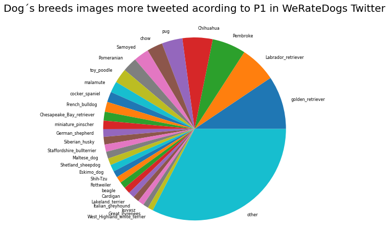

### In fact, according to the above graph, the top tweeted breed was:

### 1st Golden retriever (like the dog below)

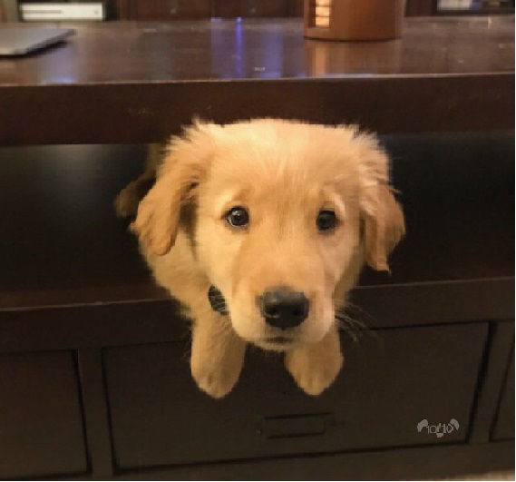

### And the other TOP 5 tweeted breeds were:

#### 2nd: Labrador retriever

#### 3rd: Pembroke

#### 4th: Chiguagua

#### 5th: Pug

### It is important to declare that for doing this graph, I used the P1 column that predicts the dog´s breed. And I had to filtered the data according to "p1_dog" in order to just analyze dog´s breeds.

### 2.- Next, I wonder which dogs breeds were the most retweeted? So what I did was to calculate the average of the retweet counts grouped by breeds. And what I found was that users who shared photos of the following dogs breeds were the TOP 5 most retweeted on average:

#### 1rst Standard_poodle

#### 2nd Afghan_hound

#### 3rd English_springer

#### 4th Saluki

#### 5th Eskimo_dog

## It is very interesting to notice that the most TWEETED dog breeds were not the most RETWEETED dog breeds.

### 3.- Finally, I wonder if there was any correlation between retweet counts and rating numerator, so now I´m going to graph this situation in the below graph.

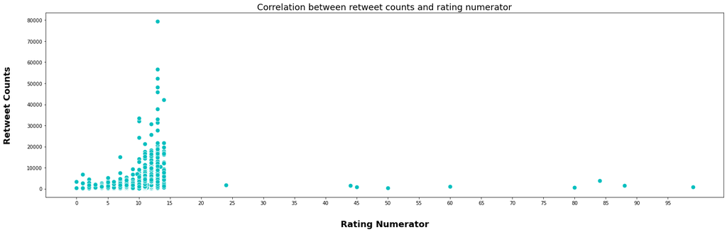

### The problem with the graph above, is there are too many outliers (even though I filtered). That´s because there were some isolated cases where rating numerator was grater than 20. So, In order to find better insights, I´m going to refilter the data to just show the most interesting part of this correlation:

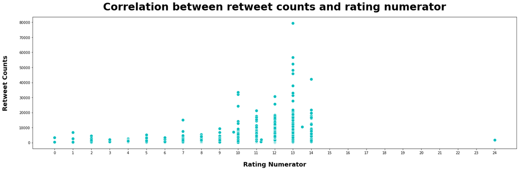

### So, with the above graph it is easier to conclude that when WeRateDogs have had shares dog´s pictures and had evaluated that picture with numerator ratings between 10-14, the "tweet" or post have had more retweets.